# Презентация к 11 л.р.

Митяков Д. А.

Российский университет дружбы народов, Москва, Россия

# Информация

## Докладчик

- Митяков Д. А.
- Российский университет дружбы народов, Москва, Россия

Открываю emacs (рис. @fig:001).

[figure not shown]

Создал файл lab07.sh с помощью комбинации Ctrl-x Ctrl-f и набрал текст из задания (рис. @fig:002).

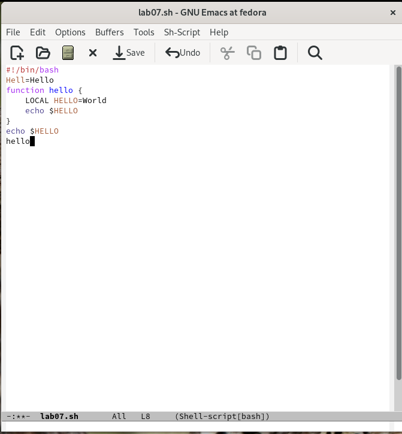

Вырезал одной командой целую строку (С-k). Вставил эту строку в конец файла (C-y). Выделил область текста (C-space). (рис. @fig:004).

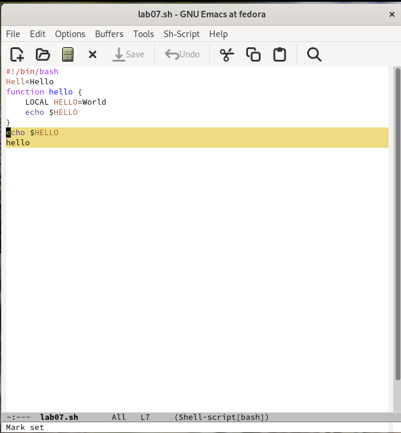

Скопировал область в буфер обмена (M-w) и вставил область в конец файла (C-y). (рис. @fig:005).

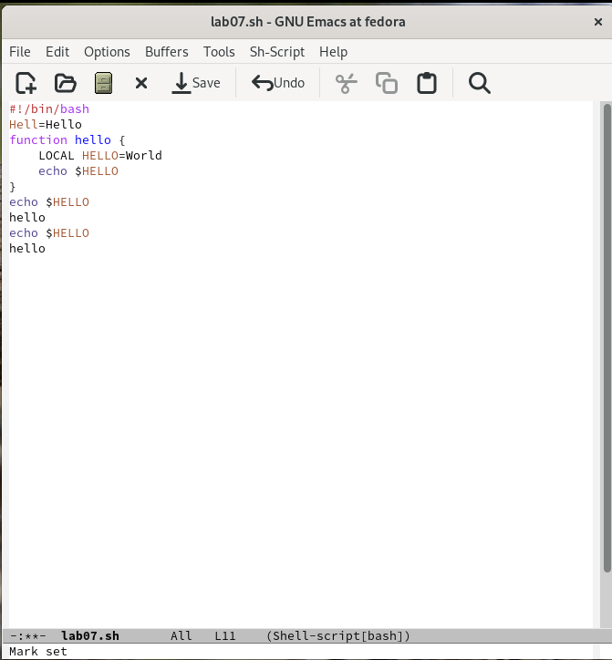

Вновь выделил эту область и на этот раз вырезал её (C-w)затем отменил последнее действие (C-/). (рис. @fig:006).

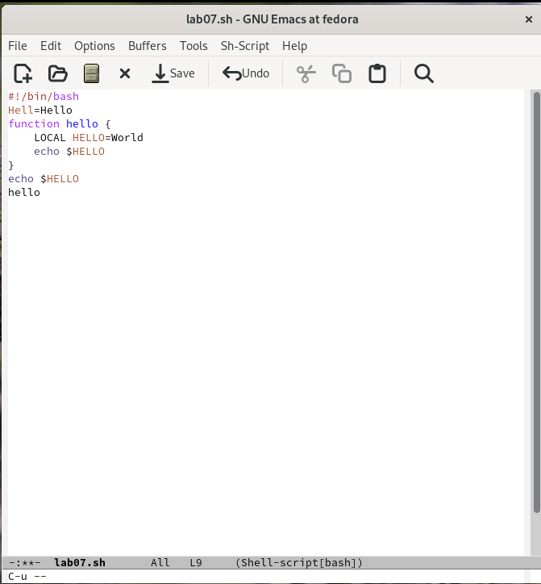

Научился использовать команды по перемещению курсора. Переместил курсор в начало строки (C-a). Переместил курсор в конец строки (C-e). Переместил курсор в начало буфера (M-<). Переместил курсор в конец буфера (M->). (рис. @fig:007).

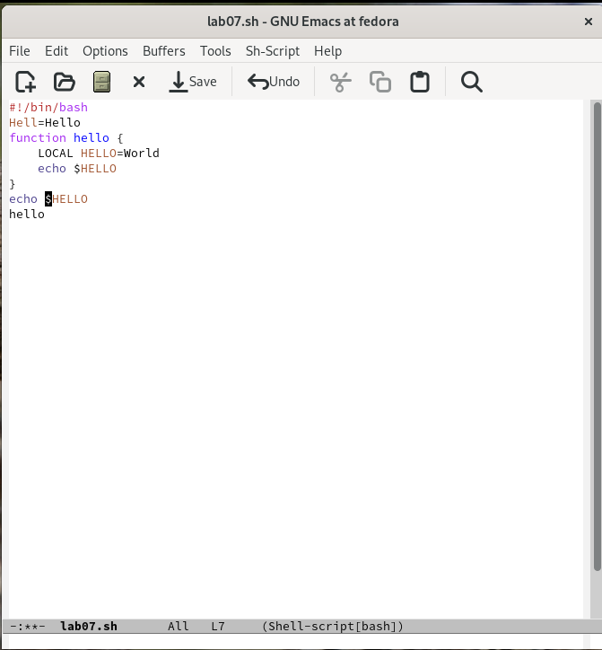

(рис. @fig:008).

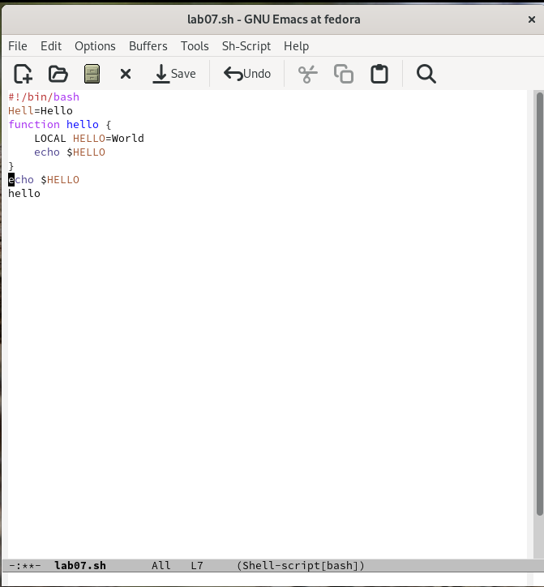

(рис. @fig:009).

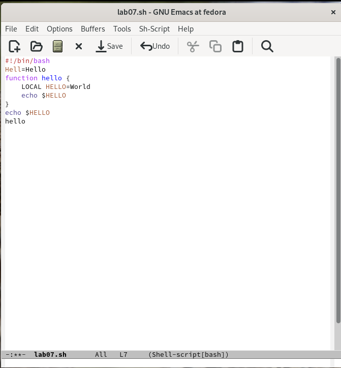

(рис. @fig:010).

[figure not shown]

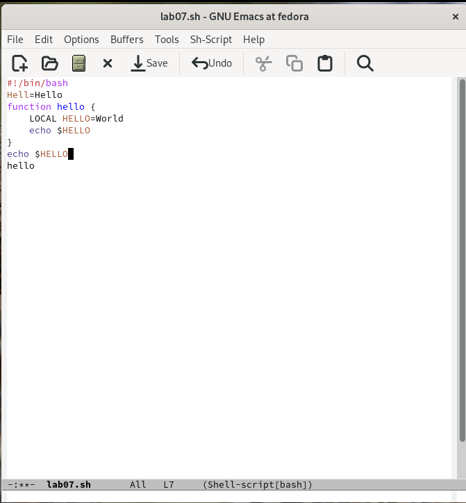

(рис. @fig:012). Вывел список активных буферов на экран (C-x C-b).

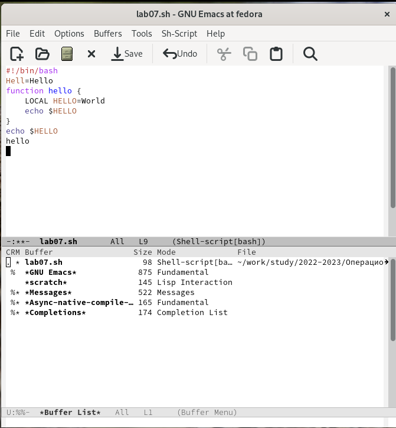

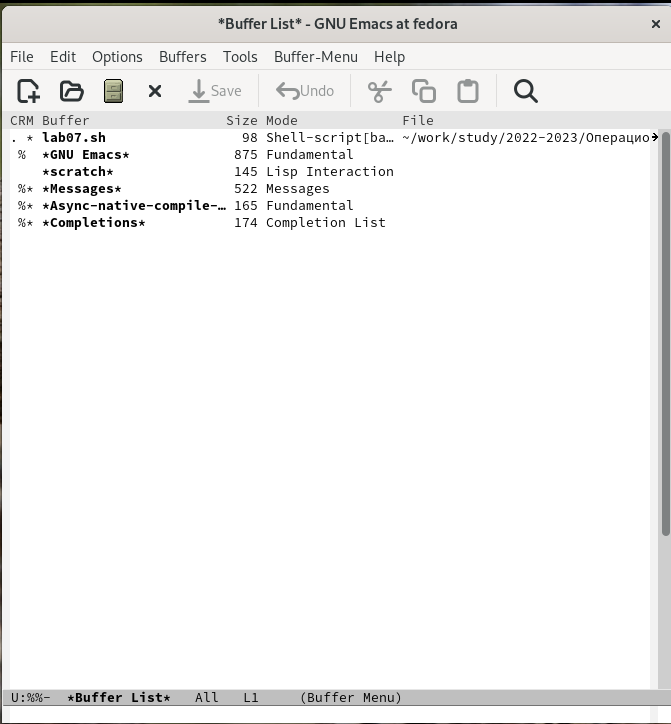

Поделил фрейм на 4 части: разделил фрейм на два окна по вертикали (C-x 3), а затем каждое из этих окон на две части по горизонтали (C-x 2) (рис. @fig:014).

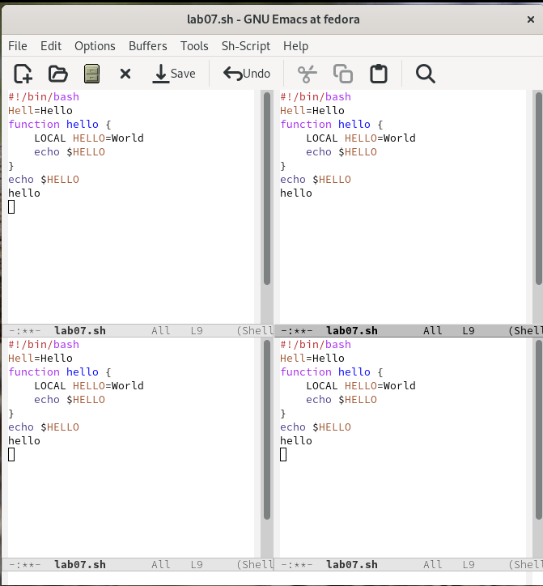

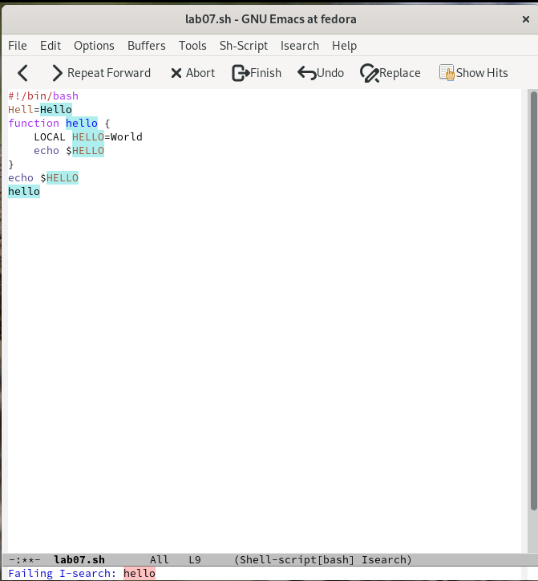

Переключился между результатами поиска, нажимая C-s, а после вышел из режима поиска, нажав C-g. (рис. @fig:016).

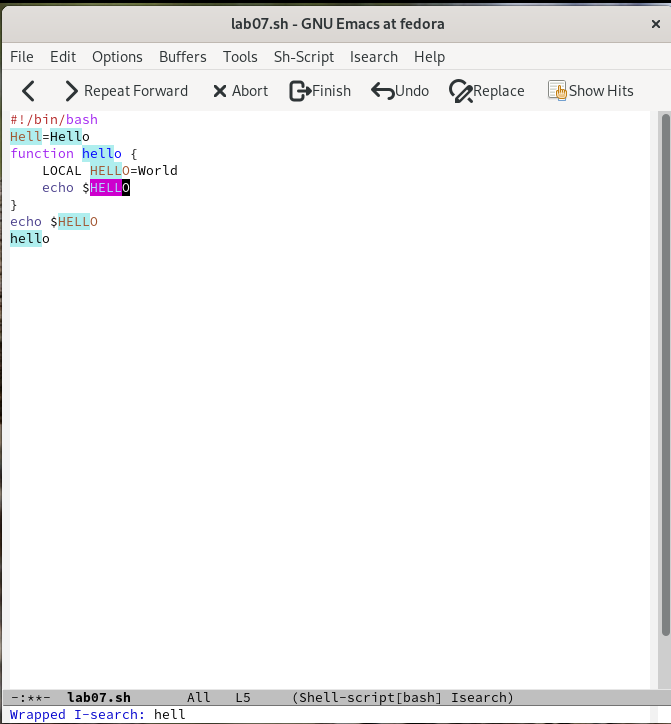